# Effective Reproduction Number: Israel vs. OECD

Itamar Caspi

2021-02-09

Abstract

The following code estimates the effective reproduction number $R_t$ for Israel and compares it to the distribution of other OECD countries’ $R_t$.

## Load packages

```r
library(tidyverse)   # for wrangling and plotting data
library(EpiEstim)    # for estimating R_t
library(lubridate)   # for handling dates
library(countrycode) # for handling country codes
library(scales)      # for dates on the x-axis
library(hrbrthemes)  # for a nice figure theme
library(zoo)         # for rolling means
library(gghighlight) # for highlighting plots
library(patchwork)   # for combining separate ggplots
library(glue)        # for pasting strings
```

## Set parameters

```r
window      <- 7   # smoothing window (days)
mean_si     <- 4.5 # mean of the serial interval
std_si      <- 3.5 # standard deviation of the serial interval
```

## Lockdown dates

```r
events <-
  tribble(
    ~date, ~event,
    # ymd("2020-09-18"), "2nd lockdown start",
    # ymd("2020-10-18"), "Exit phase 1",
    # ymd("2020-11-01"), "Exit phase 2",
    # ymd("2020-11-08"), "Exit phase 3",
    ymd("2020-12-27"),   "3rd lockdown",
    ymd("2021-01-07"),   "3rd lockdown tightening",
    ymd("2021-01-07"),   "Exit phase 1"
  )
```

## Read data

Download cases and tests data from [OWID GitHub repo](https://github.com/owid/covid-19-data/tree/master/public/data)

```r
df_cases_raw <-
  read_csv(
    "https://raw.githubusercontent.com/owid/covid-19-data/master/public/data/jhu/new_cases_per_million.csv"
  )
```

## Filter OECD countries

A list with names of OECD countries

```r
oecd_names <- c(
  "Israel", "Austria", "Belgium", "Czech Republic",
  "Denmark", "Estonia", "Finland", "France",
  "Germany", "Greece", "Hungary", "Iceland",
  "Ireland", "Italy", "Latvia", "Luxembourg",
  "Netherlands", "Norway", "Poland", "Portugal",
  "Slovak Republic", "Slovenia", "Spain",
  "Sweden", "Switzerland", "United Kingdom",  "Canada",
  "Chile", "Mexico", "United States", "Australia",
  "Japan", "Korea", "New Zealand", "Turkey"
)
```

Transform country names to iso3c codes using the [`{countrycode}`](https://cran.r-project.org/web/packages/countrycode/countrycode.pdf) package

```r
oecd_iso3c <-
  countrycode(
    oecd_names,
    origin = "country.name",
    destination = "iso3c"
  )
```

Filter OECD countries and tidy the data

```r
df_cases <-
  df_cases_raw %>%
  pivot_longer(-date, names_to = "country", values_to = "cases") %>%
  mutate(iso3c = countrycode(country, "country.name", "iso3c")) %>%
  select(date, iso3c, cases) %>%
  filter(iso3c %in% oecd_iso3c)
```

## Set smoothing window

Here `window` holds the size of the window (default is 7 days)

```r
obs <- nrow(
  df_cases %>%
    filter(iso3c == "ISR", date >= ymd("2020-09-15"))
)

t_start <- seq(2, obs - window + 1)
t_end   <- t_start + window - 1
```

## A function that estimates $R_t$

We now write a simple function that extracts $R_t$ for a given country using the [`{EpiEstim}`](https://cran.r-project.org/web/packages/EpiEstim/index.html) package

```r
extract_R <- function(incid, output, t_start, t_end, mean_si, std_si) {

  model <-
    estimate_R(
      incid = incid,
      method = "parametric_si",
      config = make_config(
        list(
          mean_si = mean_si,
          std_si = std_si,
          t_start = t_start,
          t_end = t_end
        )
      )
    )

  rep_num <- model$R[[3]]

  output <-cbind(output, rep_num)

  return(output)
}
```

## Estimate $R_t$ for OECD countries

Estimate $R_t$ for each OECD country, and ignore those for which the function throws an error (probably due to data issues).

```r
output <- c()

for (i in oecd_iso3c){

  incid <-
    df_cases %>%
    filter(
      date >= ymd("2020-09-15"),
      iso3c == i
    ) %>%
    select(date, cases) %>%
    rename(dates = date, I = cases)

  tryCatch(
  output <- extract_R(incid, output, t_start, t_end, mean_si, std_si),
  error = function(e) e
  )

}
```

## Estimate $R_t$ for Israel

Now we estimate Israel $R_t$ and add it to the output table.

```r
incid <-
  df_cases %>%
  filter(
    date >= ymd("2020-09-15"),
    iso3c == "ISR"
  ) %>%
  select(date, cases) %>%
  rename(dates = date, I = cases)

model <-
  estimate_R(
    incid = incid,
    method = "parametric_si",
    config = make_config(
        list(
          mean_si = mean_si,
          std_si = std_si,
          t_start = t_start,
          t_end = t_end
        )
      )
  )

isr_rep_num <-
  model$R %>%
  select(3) %>%
  pull()

output <-
  cbind(isr_rep_num, output)
```

## Calculate median and interquartile range

### $R_t$

Dataframe to tibble

```r
df_R <-
  output %>%
  as_tibble()
```

Calculate the median and the interquartile range, by rows (i.e., dates)

```r
df_R_q <-
  df_R %>%
  rowwise() %>%
  mutate(
    q50    = quantile((c_across(rep_num:V32)), probs = 0.50),
    q_up   = quantile((c_across(rep_num:V32)), probs = 0.75),
    q_down = quantile((c_across(rep_num:V32)), probs = 0.25)
  ) %>%
  select(isr_rep_num, starts_with("q")) %>%
  ungroup() %>%
  mutate(
    date = seq(from = ymd("2020-09-12"), by = "1 day", length.out = dim(output)[[1]])
  )
```

### Cases

Generate 7-day rolling mean of daily cases

```r
df_cases_ma <-
  df_cases %>%
  group_by(iso3c) %>%
  mutate(
    cases = rollmean(cases, 7, na.pad=TRUE, align="right")
  ) %>%
  ungroup() %>%
  select(date, iso3c, cases)
```

Calculate the median and interquartile range, by rows (i.e., dates)

```r
df_cases_q <-
  df_cases_ma %>%
  pivot_wider(names_from = "iso3c", values_from = "cases") %>%
  rowwise() %>%
  mutate(
    q50    = quantile((c_across(AUS:USA)), probs = 0.50, na.rm = TRUE),
    q_up   = quantile((c_across(AUS:USA)), probs = 0.75, na.rm = TRUE),
    q_down = quantile((c_across(AUS:USA)), probs = 0.25, na.rm = TRUE)
  ) %>%
  select(date, ISR, starts_with("q")) %>%
  ungroup()
```

## Plot

Set start date for all figures

```r
plot_start <- ymd("2020-12-15")
```

Set caption by source

```r
data_source_name <- "JHU-CSSE, OWID"
```

### $R_t$

Store information regarding the latest values (will be used in the plot to annotate the lines.)

```r
last_obs <- df_R_q %>%
  slice(dim(output)[[1]])

last_date   <- last_obs %>% pull(date)
last_oecd   <- last_obs %>% pull(q50) %>% round(2) %>% unname()
last_israel <- last_obs %>% pull(isr_rep_num) %>% round(2) %>% unname()

label_israel <- paste0("Israel\n", last_israel %>% format(nsmall = 2))
label_oecd   <- paste0("OECD\n", last_oecd %>% format(nsmall = 2))
```

Plot $R_t$

```r
p_R <- df_R_q %>%
  filter(
    date >= plot_start
  ) %>%
  ggplot(aes(x = date, y = q50)) +
  geom_line(
    aes(x = date, y = q50, color = "OECD median"),
    size = 1,
    color = "#2d003f"
  ) +
  geom_line(
    aes(x = date, y = isr_rep_num),
    color = "#05827e",
    size = 1,
  ) +
  geom_ribbon(
    aes(ymin = q_down, ymax = q_up),
    fill = "#2d003f",
    alpha = 0.1
  ) +
  geom_hline(aes(yintercept = 1), color = "black", size = 0.5) +
  annotate("rect", fill = "#ffe612", xmin = last_date, xmax = last_date + days(10), ymin = -Inf, ymax = +Inf, alpha = 0.4) +
  geom_vline(data = events, aes(xintercept = date), linetype = 2) +
  geom_text(data = events, aes(x=date, y=0.5, label=event), size=3, angle=90, vjust=-0.4, hjust=0) +
  annotate("label", x = last_date + days(1), y = last_oecd-0.05, label = label_oecd, color = "#2d003f", size = 3.5) +
  annotate("label", x = last_date + days(1), y = last_israel+0.05, label = label_israel, color = "#05827e", size = 3.5) +
  labs(
    y = expression("R"[t]),
    x = "",
    title = "Effective Reproduction Number",
    subtitle = "Israel vs. OECD median and interquartile range",
    color = "",
    lty = "",
    caption = glue("Notes: Yellow shaded area denotes the 10-days between infection and outpatiant testing.\nData: {data_source_name}.")
  ) +
  scale_x_date(labels = date_format("%d-%m")) +
  theme(
    legend.position="top",
    plot.caption = element_text(hjust = 0)
  ) +
  ylim(0.5,1.5)

# p_R
```

### New cases

Store information regarding the latest values (will be used in the plot to annotate the lines.)

```r
last_obs <- df_cases_q %>%
  slice(dim(df_cases_q)[[1]])

last_date   <- last_obs %>% pull(date)
last_oecd   <- last_obs %>% pull(q50) %>% round(0) %>% unname()
last_israel <- last_obs %>% pull(ISR) %>% round(0) %>% unname()

label_israel <- paste0("Israel\n", last_israel)
label_oecd   <- paste0("OECD\n", last_oecd)
```

Plot daily new cases

```r
p_cases <-
  df_cases_q %>%
  filter(
    date >= plot_start
  ) %>%
  ggplot(aes(x = date, y = q50)) +
  geom_line(
    aes(x = date, y = q50, color = "OECD median"),
    size = 1,
    color = "#2d003f"
  ) +
  geom_line(
    aes(x = date, y = ISR),
    color = "#05827e",
    size = 1,
  ) +
  geom_ribbon(
    aes(ymin = q_down, ymax = q_up),
    fill = "#2d003f",
    alpha = 0.1
  ) +
  annotate("label", x = last_date + days(1), y = last_oecd, label = label_oecd, color = "#2d003f", size = 3.5) +
  annotate("label", x = last_date + days(1), y = last_israel, label = label_israel, color = "#05827e", size = 3.5) +
  geom_vline(data = events, aes(xintercept = date), linetype = 2) +
  geom_text(data = events, aes(x=date, y=0, label=event), size=3, angle=90, vjust=-0.4, hjust=0) +
  labs(
    title = "New Cases Per 1 Million",
    subtitle = "Israel vs. OECD median and interquartile range",
    y = "Daily cases per 1 million",
    x = "",
    caption = glue("Notes: 7-day moving average\nData: {data_source_name}.")
  ) +
  scale_x_date(labels = date_format("%d-%m")) +
  theme(
    legend.position="top",
    plot.caption = element_text(hjust = 0)
  )

# p_cases
```

## Save output

Save data to a csv file.

```r
write_csv(df_R_q, path = "output/oecd-rep-num.csv")
write_csv(df_cases_q, path = "output/oecd-cases.csv")
```

plot side $R_t$ and cases by side using [`{patchwork}`](https://patchwork.data-imaginist.com/) and save as `png`.

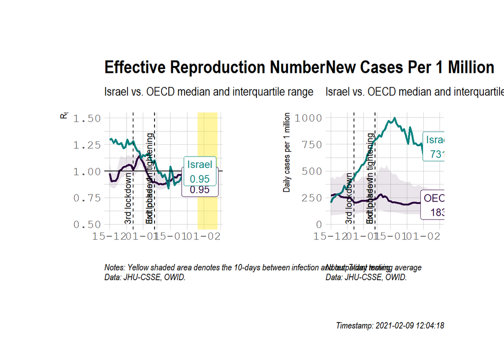

```r
p <- p_R + p_cases +
  plot_annotation(caption = paste0("Timestamp: ", now())) &
  theme(text = element_text('mono', size = 14))

p
```

```r
ggsave(
  filename = "plots/r-cases-oecd.png",
  plot = p,
  scale = 2
)
```

## References

Cori, A., Ferguson, N. M., Fraser, C., & Cauchemez, S. (2013). A new framework and software to estimate time-varying reproduction numbers during epidemics. *American Journal of Epidemiology*, 178(9), 1505-1512.

Gostic, K. M., McGough, L., Baskerville, S. A., Joshi, K., Tedijanto, C., Kahn, R., … & Meakin, S. (2020). Practical considerations for measuring the effective reproductive number, Rt. *medRxiv*.